# Lending Club Loan Analysis

Jonathan Schild, Medhasweta Sen, Brian Gulko

2022-10-25

```r
library(ezids)
```

# 1 Introduction

The Kaggle site gives descriptions for the variables. Here is what we know:

```r
data_definitions <- data.frame(variable = c("credit.policy", "purpose", "int.rate", "installment", "log.annual.inc", "dti", "fico", "days.with.cr.line", "revol.bal", "revol.util", "inq.last.6mths", "delinq.2yrs", "pub.rec", "not.fully.paid"),
                          definition = c("1 if the customer meets the credit underwriting criteria of LendingClub.com, and 0 otherwise.",
                                         "The purpose of the loan (takes values creditcard, debtconsolidation, educational, majorpurchase, smallbusiness, and all_other).",
                                         "The interest rate of the loan, as a proportion (a rate of 11% would be stored as 0.11). Borrowers judged by LendingClub.com to be more risky are assigned higher interest rates.",
                                         "The monthly installments owed by the borrower if the loan is funded.",
                                         "The natural log of the self-reported annual income of the borrower.",
                                         "The debt-to-income ratio of the borrower (amount of debt divided by annual income).",
                                         "The FICO credit score of the borrower.",
                                         "The number of days the borrower has had a credit line.",
                                         "The borrower's revolving balance (amount unpaid at the end of the credit card billing cycle).",
                                         "The borrower's revolving line utilization rate (the amount of the credit line used relative to total credit available).",
                                         "The borrower's number of inquiries by creditors in the last 6 months.",
                                         "The number of times the borrower had been 30+ days past due on a payment in the past 2 years.",
                                         "The borrower's number of derogatory public records (bankruptcy filings, tax liens, or judgments).",
                                         "Whether the borrower will be fully paid or not."))
```

```r
knitr::kable(data_definitions)
```

| variable | definition |
| --- | --- |
| credit.policy | 1 if the customer meets the credit underwriting criteria of LendingClub.com, and 0 otherwise. |
| purpose | The purpose of the loan (takes values creditcard, debtconsolidation, educational, majorpurchase, smallbusiness, and all_other). |
| int.rate | The interest rate of the loan, as a proportion (a rate of 11% would be stored as 0.11). Borrowers judged by LendingClub.com to be more risky are assigned higher interest rates. |
| installment | The monthly installments owed by the borrower if the loan is funded. |
| log.annual.inc | The natural log of the self-reported annual income of the borrower. |
| dti | The debt-to-income ratio of the borrower (amount of debt divided by annual income). |
| fico | The FICO credit score of the borrower. |
| days.with.cr.line | The number of days the borrower has had a credit line. |
| revol.bal | The borrower’s revolving balance (amount unpaid at the end of the credit card billing cycle). |
| revol.util | The borrower’s revolving line utilization rate (the amount of the credit line used relative to total credit available). |
| inq.last.6mths | The borrower’s number of inquiries by creditors in the last 6 months. |
| delinq.2yrs | The number of times the borrower had been 30+ days past due on a payment in the past 2 years. |
| pub.rec | The borrower’s number of derogatory public records (bankruptcy filings, tax liens, or judgments). |
| not.fully.paid | Whether the borrower will be fully paid or not. |

# 2 EDA Checklist

For our exploratory data analysis, we will start by following the checklist in *The Art of Data Science* chapter 4. These are the 9 elements of the checklist:

1. Formulate your question
2. Read in your data
3. Check the packaging
4. Look at the top and the bottom of your data
5. Check your “n”s
6. Validate with at least one external data source
7. Make a plot
8. Try the easy solution first
9. Follow up

## 2.2 Read in your data

```r
library(tidyverse)
# read_csv vs read.csv
loans <- read.csv("lending_club_loan_data.csv")
```

## 2.3 Check the packaging

This dataset has 9578 rows and 14 columns.

## 2.4 Look at the top and the bottom of your data

The top looks like this:

```r
xkabledplyhead(loans)
```

Head

| credit.policy | purpose | int.rate | installment | log.annual.inc | dti | fico | days.with.cr.line | revol.bal | revol.util | inq.last.6mths | delinq.2yrs | pub.rec | not.fully.paid |
| --- | --- | --- | --- | --- | --- | --- | --- | --- | --- | --- | --- | --- | --- |
| 1 | debt_consolidation | 0.1189 | 829.10 | 11.3504 | 19.48 | 737 | 5639.958 | 28854 | 52.1 | 0 | 0 | 0 | 0 |
| 1 | credit_card | 0.1071 | 228.22 | 11.0821 | 14.29 | 707 | 2760.000 | 33623 | 76.7 | 0 | 0 | 0 | 0 |
| 1 | debt_consolidation | 0.1357 | 366.86 | 10.3735 | 11.63 | 682 | 4710.000 | 3511 | 25.6 | 1 | 0 | 0 | 0 |
| 1 | debt_consolidation | 0.1008 | 162.34 | 11.3504 | 8.10 | 712 | 2699.958 | 33667 | 73.2 | 1 | 0 | 0 | 0 |
| 1 | credit_card | 0.1426 | 102.92 | 11.2997 | 14.97 | 667 | 4066.000 | 4740 | 39.5 | 0 | 1 | 0 | 0 |

The bottom looks like this:

```r
xkabledplytail(loans)
```

Tail

|  | credit.policy | purpose | int.rate | installment | log.annual.inc | dti | fico | days.with.cr.line | revol.bal | revol.util | inq.last.6mths | delinq.2yrs | pub.rec | not.fully.paid |
| --- | --- | --- | --- | --- | --- | --- | --- | --- | --- | --- | --- | --- | --- | --- |
| 9574 | 0 | all_other | 0.1461 | 344.76 | 12.1808 | 10.39 | 672 | 10474.000 | 215372 | 82.1 | 2 | 0 | 0 | 1 |
| 9575 | 0 | all_other | 0.1253 | 257.70 | 11.1419 | 0.21 | 722 | 4380.000 | 184 | 1.1 | 5 | 0 | 0 | 1 |
| 9576 | 0 | debt_consolidation | 0.1071 | 97.81 | 10.5966 | 13.09 | 687 | 3450.042 | 10036 | 82.9 | 8 | 0 | 0 | 1 |
| 9577 | 0 | home_improvement | 0.1600 | 351.58 | 10.8198 | 19.18 | 692 | 1800.000 | 0 | 3.2 | 5 | 0 | 0 | 1 |
| 9578 | 0 | debt_consolidation | 0.1392 | 853.43 | 11.2645 | 16.28 | 732 | 4740.000 | 37879 | 57.0 | 6 | 0 | 0 | 1 |

## 2.5 Check your “n”s

Let’s take a look at the overall structure of the dataset:

```r
str(loans)
```

```
## 'data.frame':    9578 obs. of  14 variables:
##  $ credit.policy    : int  1 1 1 1 1 1 1 1 1 1 ...
##  $ purpose          : chr  "debt_consolidation" "credit_card" "debt_consolidation" "debt_consolidation" ...
##  $ int.rate         : num  0.119 0.107 0.136 0.101 0.143 ...
##  $ installment      : num  829 228 367 162 103 ...
##  $ log.annual.inc   : num  11.4 11.1 10.4 11.4 11.3 ...
##  $ dti              : num  19.5 14.3 11.6 8.1 15 ...
##  $ fico             : int  737 707 682 712 667 727 667 722 682 707 ...
##  $ days.with.cr.line: num  5640 2760 4710 2700 4066 ...
##  $ revol.bal        : int  28854 33623 3511 33667 4740 50807 3839 24220 69909 5630 ...
##  $ revol.util       : num  52.1 76.7 25.6 73.2 39.5 51 76.8 68.6 51.1 23 ...
##  $ inq.last.6mths   : int  0 0 1 1 0 0 0 0 1 1 ...
##  $ delinq.2yrs      : int  0 0 0 0 1 0 0 0 0 0 ...
##  $ pub.rec          : int  0 0 0 0 0 0 1 0 0 0 ...
##  $ not.fully.paid   : int  0 0 0 0 0 0 1 1 0 0 ...
```

We see that there is only one character variable, and some of the numeric variables look like Logicals. Now let’s look at the summary:

```r
xkablesummary(loans)
```

Table: Statistics summary.

|  | credit.policy | purpose | int.rate | installment | log.annual.inc | dti | fico | days.with.cr.line | revol.bal | revol.util | inq.last.6mths | delinq.2yrs | pub.rec | not.fully.paid |
| --- | --- | --- | --- | --- | --- | --- | --- | --- | --- | --- | --- | --- | --- | --- |
| Min | Min. :0.000 | Length:9578 | Min. :0.0600 | Min. : 15.67 | Min. : 7.548 | Min. : 0.000 | Min. :612.0 | Min. : 179 | Min. : 0 | Min. : 0.0 | Min. : 0.000 | Min. : 0.0000 | Min. :0.00000 | Min. :0.0000 |
| Q1 | 1st Qu.:1.000 | Class :character | 1st Qu.:0.1039 | 1st Qu.:163.77 | 1st Qu.:10.558 | 1st Qu.: 7.213 | 1st Qu.:682.0 | 1st Qu.: 2820 | 1st Qu.: 3187 | 1st Qu.: 22.6 | 1st Qu.: 0.000 | 1st Qu.: 0.0000 | 1st Qu.:0.00000 | 1st Qu.:0.0000 |
| Median | Median :1.000 | Mode :character | Median :0.1221 | Median :268.95 | Median :10.929 | Median :12.665 | Median :707.0 | Median : 4140 | Median : 8596 | Median : 46.3 | Median : 1.000 | Median : 0.0000 | Median :0.00000 | Median :0.0000 |
| Mean | Mean :0.805 | NA | Mean :0.1226 | Mean :319.09 | Mean :10.932 | Mean :12.607 | Mean :710.8 | Mean : 4561 | Mean : 16914 | Mean : 46.8 | Mean : 1.577 | Mean : 0.1637 | Mean :0.06212 | Mean :0.1601 |
| Q3 | 3rd Qu.:1.000 | NA | 3rd Qu.:0.1407 | 3rd Qu.:432.76 | 3rd Qu.:11.291 | 3rd Qu.:17.950 | 3rd Qu.:737.0 | 3rd Qu.: 5730 | 3rd Qu.: 18250 | 3rd Qu.: 70.9 | 3rd Qu.: 2.000 | 3rd Qu.: 0.0000 | 3rd Qu.:0.00000 | 3rd Qu.:0.0000 |
| Max | Max. :1.000 | NA | Max. :0.2164 | Max. :940.14 | Max. :14.528 | Max. :29.960 | Max. :827.0 | Max. :17640 | Max. :1207359 | Max. :119.0 | Max. :33.000 | Max. :13.0000 | Max. :5.00000 | Max. :1.0000 |

From this we can see that some of the variables that appeared to be Logicals, like inq.last.6mths, delinq.2yrs, and pub.rec are actually not.

There are a few variables that we have an idea about what they should look like. Let’s check them.

Looking at the interest rate, the range is 0.06, 0.2164, or between 6% and 21.64%, which aligns with our expectations.

The range of the FICO scores is 612, 827, which also aligns with what we would expect.

The range of the utilization is 0, 119, which doesn’t entirely make sense that the percent utilization would be more than 100. We will need to look into this further.

## 2.6 Validate with at least one external data source

According to the Kaggle site where we got this dataset from, there are 9,578 rows and 14 columns, which matches what we have. The site also shows that there is no missing data. Let’s verify that by adding the total number of missing cells in the dataset, which is 0.

## 2.7 Make a plot

Let’s make a histogram for each non-Logical numeric variable.

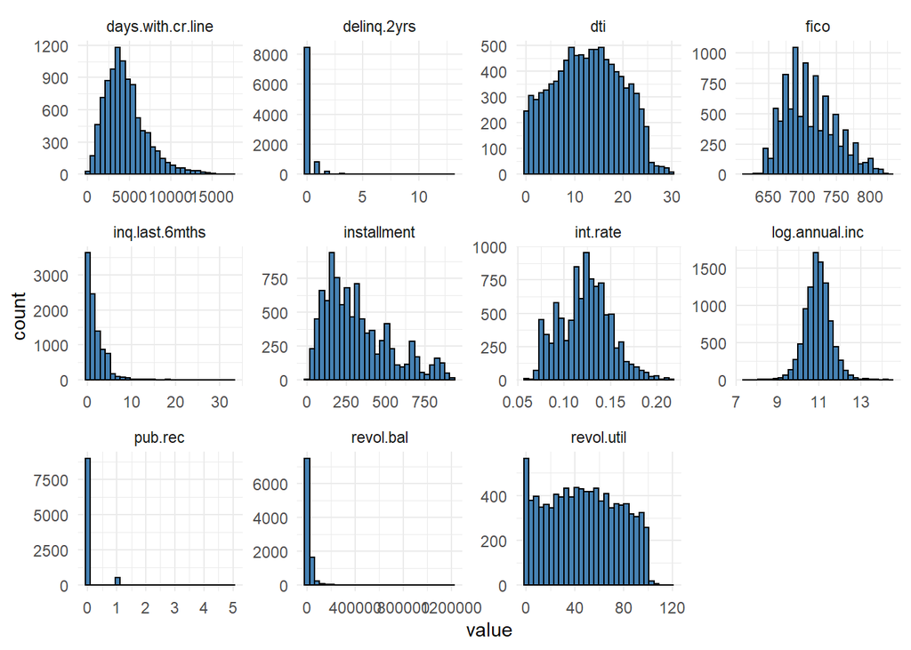

```r
loans %>%
  gather(variable, value,
         c(int.rate, installment, log.annual.inc, dti, fico, days.with.cr.line, revol.bal, revol.util,
           inq.last.6mths, delinq.2yrs, pub.rec)) %>%
  ggplot(aes(x = value)) +
  geom_histogram(fill = "steelblue", color = "black") +
  facet_wrap(~ variable, scales = "free") +
  theme_minimal()
```

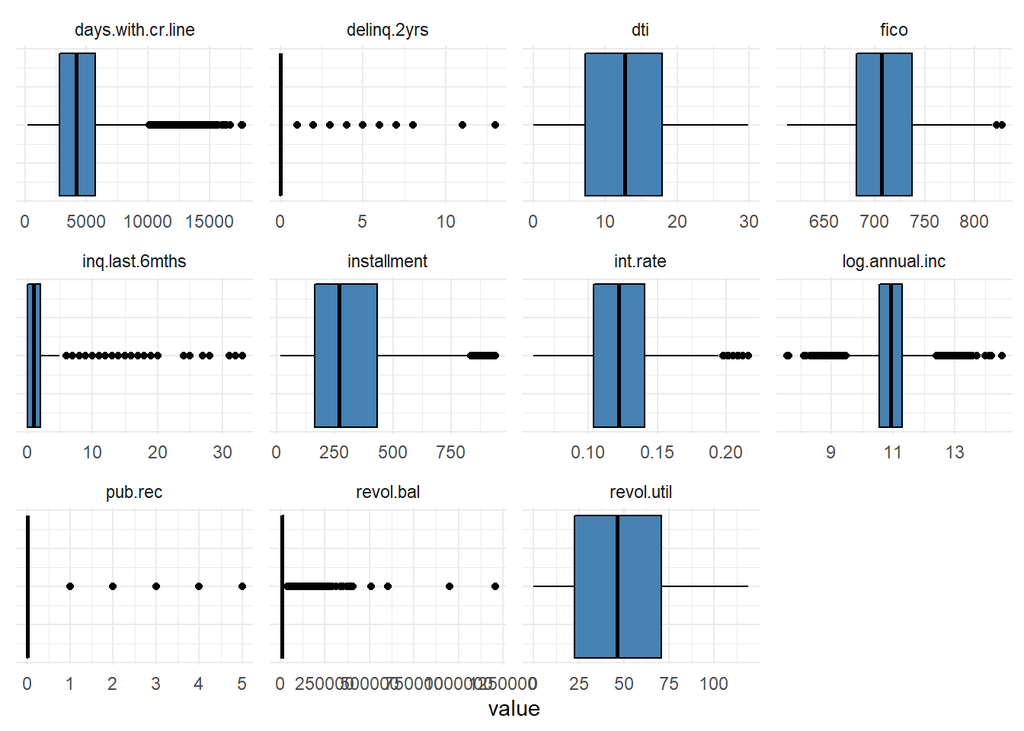

```r
loans %>%
  gather(variable, value,
         c(int.rate, installment, log.annual.inc, dti, fico, days.with.cr.line, revol.bal, revol.util,
           inq.last.6mths, delinq.2yrs, pub.rec)) %>%
  ggplot(aes(x = value)) +
  geom_boxplot(fill = "steelblue", color = "black") +
  facet_wrap(~ variable, scales = "free") +
  theme_minimal() +
  theme(axis.text.y = element_blank(), axis.ticks.y = element_blank())
```

We can see that some of these variables have issues with outliers.

Now let’s look at the Factor and Logical variables with bar charts.

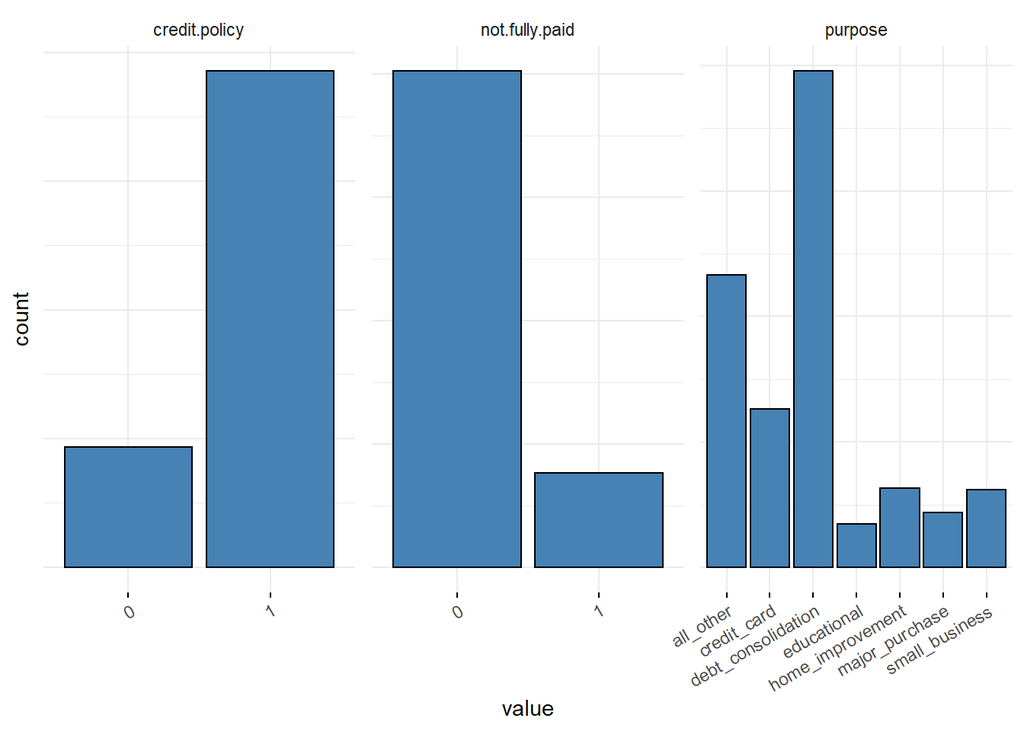

```r
loans %>%
  gather(variable, value,
         c(credit.policy, purpose, not.fully.paid)) %>%
  ggplot(aes(x = value)) +
  geom_bar(fill = "steelblue", color = "black") +
  facet_wrap(~ variable, scales = "free") +
  theme_minimal() +
  theme(axis.text.y = element_blank(), axis.ticks.y = element_blank(), axis.text.x = element_text(angle = 30, hjust = 1, vjust = 1),
        axis.ticks.x = element_line())
```

## 2.8 Try the easy solution first

Let’s try the easy way of looking at meeting the credit underwriting criteria vs the borrower fully paying. We can group by the credit.policy variable, and calculate the percentage of borrowers in each category who did not fully pay.

```r
# Create a better table for this
loans %>%
  group_by(credit.policy) %>%
  summarize(mean(not.fully.paid)) %>%
  ungroup() %>%
  knitr::kable()
```

| credit.policy | mean(not.fully.paid) |
| --- | --- |
| 0 | 0.2778373 |
| 1 | 0.1315175 |

From this we can see that about 13.2% of borrowers who met the credit underwriting criteria did not fully pay, while for the borrowers who did not meet the credit underwriting criteria about 27.8% did not fully pay.

## 2.9 Follow up

Let us go back to the table of data definitions and add a column for the variable type.

```r
data_definitions_augmented <- data_definitions %>%
  mutate(type = c("Logical", "Factor", "Numeric", "Numeric", "Numeric", "Numeric", "Integer", "Numeric", "Integer", "Numeric", "Integer", "Integer", "Integer", "Logical")) %>%
  select(variable, type, definition)
```

```r
knitr::kable(data_definitions_augmented)
```

| variable | type | definition |
| --- | --- | --- |
| credit.policy | Logical | 1 if the customer meets the credit underwriting criteria of LendingClub.com, and 0 otherwise. |
| purpose | Factor | The purpose of the loan (takes values creditcard, debtconsolidation, educational, majorpurchase, smallbusiness, and all_other). |
| int.rate | Numeric | The interest rate of the loan, as a proportion (a rate of 11% would be stored as 0.11). Borrowers judged by LendingClub.com to be more risky are assigned higher interest rates. |
| installment | Numeric | The monthly installments owed by the borrower if the loan is funded. |
| log.annual.inc | Numeric | The natural log of the self-reported annual income of the borrower. |
| dti | Numeric | The debt-to-income ratio of the borrower (amount of debt divided by annual income). |
| fico | Integer | The FICO credit score of the borrower. |
| days.with.cr.line | Numeric | The number of days the borrower has had a credit line. |
| revol.bal | Integer | The borrower’s revolving balance (amount unpaid at the end of the credit card billing cycle). |
| revol.util | Numeric | The borrower’s revolving line utilization rate (the amount of the credit line used relative to total credit available). |
| inq.last.6mths | Integer | The borrower’s number of inquiries by creditors in the last 6 months. |
| delinq.2yrs | Integer | The number of times the borrower had been 30+ days past due on a payment in the past 2 years. |
| pub.rec | Integer | The borrower’s number of derogatory public records (bankruptcy filings, tax liens, or judgments). |
| not.fully.paid | Logical | Whether the borrower will be fully paid or not. |

Let’s also convert some of the variables to a more appropriate type

```r
loans$credit.policy <- as.logical(loans$credit.policy)
loans$not.fully.paid <- as.logical(loans$not.fully.paid)

loans$purpose <- as.factor(loans$purpose)
```

# 3 Additional EDA

# 4 Statistical Tests

# 5 Conclusion